# Identitas Mahasiswa

| Nama Lengkap | Nama Panggilan | NIM |
| --- | --- | --- |
| Damara Zata Amani | Damara | 23101910050 |

# Packages

```python
import pandas as pd
import numpy as np
import matplotlib.pyplot as plt
import seaborn as sns
import sklearn.neighbors
from pandas import read_excel, merge, set_option

pd.set_option('display.max_columns', None)
%matplotlib inline
sns.set(style='darkgrid')
params = {'font.family': 'Times New Roman', 'axes.labelsize': 14, 'xtick.labelsize': 14,
          'ytick.labelsize': 14, 'axes.labelweight': 'bold'}
plt.rcParams.update(params)
```

# Dataset

```python
original1=pd.read_excel("Customer Data.xlsx",index_col="mdm_id")
original1.head()
```

| mdm_id | id_type | gender | age | carrier | make | model | os | os_version | home_country | home_geohash | home_lat | home_lon | work_geohash | work_lat | work_lon | device_price | affluence | brands_visited | place_categories | geo_behaviour | interests | travelled_countries | app_usage | age_group | broadband | cellular | home_prop | home_kab | home_kec | … |
| --- | --- | --- | --- | --- | --- | --- | --- | --- | --- | --- | --- | --- | --- | --- | --- | --- | --- | --- | --- | --- | --- | --- | --- | --- | --- | --- | --- | --- | --- | --- |
| 77fa83ed01e72b523d6756e21b****** | GAID | male | 23 | pt. wireless indonesia | 9 | redmi note 8 | android | 9 | IDN | qqtukfjg | -7.678843 | 109.552746 | qqtumhd | -7.665024 | 109.559097 | 198.0 | Low-Affluent | NaN | NaN | NaN | Sports,Arts and Crafts,Photography,Technology ... | NaN | SOCIAL,PRODUCTIVITY,TOOLS,PHOTOGRAPHY | 18-24 | PT. Jinom Network Indonesia | NaN | Jawa Tengah | Kebumen | Adimulyo | … |
| eb11655ad25c779e714380eadf****** | GAID | male | 35 | indosat internet network provider | xiaomi | redmi 5 | android | 7.1 | IDN | qqguyunc | -6.174059 | 106.829510 | qqguyunc | -6.174059 | 106.829510 | 172.0 | Low-Affluent | Apotek Visitors,Roti bakar 88 Visitors,Alfamid... | Places Of Worship Visitors,Sporting Goods Shop... | Job Seekers,In-Market Personal Loans,DIY Enthu... | Business,Television,Technology & Computing,Web... | MYS,SGP | NaN | 35-44 | NaN | indosat internet network provider | Dki Jakarta | Kota Jakarta Pusat | Gambir | … |
| 9bbba1a492ebdab5c9f72c3551****** | GAID | male | 45 | telkomsel | oppo | cph1989 | android | 10 | IDN | NaN | NaN | NaN | qqgmtxe1 | -6.022997 | 106.066303 | 0.0 | NaN | NaN | NaN | NaN | NaN | NaN | SOCIAL,TOOLS | 45-54 | NaN | telkomsel | NaN | NaN | NaN | … |
| 8172c382bf0233a182e7626ff6****** | GAID | NaN | 51 | pt. wireless indonesia | oppo | cph1909 | android | 8.1 | IDN | qqguyunc | -6.174059 | 106.829510 | qqguyunc | -6.174059 | 106.829510 | NaN | NaN | NaN | NaN | NaN | NaN | NaN | NaN | 45-54 | NaN | NaN | Dki Jakarta | Kota Jakarta Pusat | Gambir | … |
| 9d17c8d650f11c2d6fc1d64d18****** | GAID | male | 28 | xl axiata | oppo | a1601 | android | 5.1 | IDN | qqycr0p | -6.810837 | 111.060104 | qqycr05h | -6.810751 | 111.054096 | 267.0 | Medium-Affluent | NaN | NaN | NaN | NaN | NaN | SOCIAL,TOOLS,PHOTOGRAPHY | 25-34 | NaN | xl axiata | Jawa Tengah | Pati | Gabus | … |

```python
original2=pd.read_csv("Customer_Data.csv",index_col="maid_md5")
original2.head()
```

| maid_md5 | maid | id_type | gender | age | carrier | make | model | os | os_version | home_country | home_geohash | work_geohash | device_price | device_age | affluence | brands_visited | place_categories | geo_behaviour | interests | travelled_countries |
| --- | --- | --- | --- | --- | --- | --- | --- | --- | --- | --- | --- | --- | --- | --- | --- | --- | --- | --- | --- | --- |
| 7c3b4df5b22df2ae7860d982e4****** | 9a58e022-5d7f-47cf-ab29-2bef91****** | GAID | male | 32.0 | indosat internet network provider | NaN | NaN | android | 11.0 | IDN | NaN | qqguxmtb | NaN | NaN | NaN | NaN | NaN | NaN | NaN | NaN |
| 93e8d97f82e4f751bfa93f2d7d****** | 17aef202-caac-4181-a368-b5d46c****** | GAID | male | 31.0 | xl axiata | NaN | NaN | android | 10.0 | IDN | NaN | NaN | NaN | NaN | NaN | NaN | NaN | NaN | NaN | NaN |
| 0d1172df74b8e8a1dd8045d38c****** | 357d914b-c1b9-415d-b048-fcd109****** | GAID | male | 32.0 | xl axiata | oppo | cph1823 | android | 10.0 | IDN | qw3ytw2 | qw3ytw2 | 339.0 | 2018_august | Medium-Affluent | NaN | Park Visitors,Recreation Centers Visitors,Coll... | Job Seekers,Parents of School Children,Family ... | NaN | NaN |
| c7db015280e371258dc2374b4e****** | 304ba207-50a4-467a-870e-3829f2****** | GAID | male | 27.0 | xl axiata | xiaomi | mi a2 lite | android | 9.0 | IDN | qqu8f6e | qqu8f6e | 267.0 | 2018_july | Medium-Affluent | Indomaret Visitors,Hans Visitors | Convenience Store Visitors,Supermarket Visitor... | Budget Travellers,Job Seekers,In-Market Insura... | Business,Technology & Computing,Web Conferenci... | NaN |
| 982af16c81f112cc69f6bdaaa2****** | f4663042-962c-467c-91fd-78a82f****** | GAID | male | 23.0 | NaN | oppo | cph1911 | android | 11.0 | IDN | w21vgpjk | w21vvts | 285.0 | 2019_may | Medium-Affluent | NaN | NaN | NaN | NaN | NaN |

```python
original1.columns
```

```
Index(['id_type', 'gender', 'age', 'carrier', 'make', 'model', 'os',
       'os_version', 'home_country', 'home_geohash', 'home_lat', 'home_lon',
       'work_geohash', 'work_lat', 'work_lon', 'device_price', 'affluence',
       'brands_visited', 'place_categories', 'geo_behaviour', 'interests',
       'travelled_countries', 'app_usage', 'age_group', 'broadband',
       'cellular', 'home_prop', 'home_kab', 'home_kec', 'home_desakel',
       'work_prop', 'work_kab', 'work_kec', 'work_desakel'],
      dtype='object')
```

```python
original2.columns
```

```
Index(['maid', 'id_type', 'gender', 'age', 'carrier', 'make', 'model', 'os',
       'os_version', 'home_country', 'home_geohash', 'work_geohash',
       'device_price', 'device_age', 'affluence', 'brands_visited',
       'place_categories', 'geo_behaviour', 'interests',
       'travelled_countries'],
      dtype='object')
```

```python
original2=original2.rename(columns={'maid_md5': 'mdm_id'})
```

```python
df=original1.combine_first(original2)
df
```

|  | affluence | age | age_group | app_usage | brands_visited | broadband | carrier | cellular | device_age | device_price | gender | geo_behaviour | home_country | home_desakel | home_geohash | home_kab | home_kec | home_lat | home_lon | home_prop | id_type | interests | maid | make | model | os | os_version | place_categories | travelled_countries | … |
| --- | --- | --- | --- | --- | --- | --- | --- | --- | --- | --- | --- | --- | --- | --- | --- | --- | --- | --- | --- | --- | --- | --- | --- | --- | --- | --- | --- | --- | --- | --- |
| 0648c865b9f4db0e91e46c866f****** | NaN | 37.0 | 35-44 | SOCIAL,LIFESTYLE | NaN | NaN | xl axiata | xl axiata | 2016_august | 0.0 | male | NaN | IDN | Ketabang | qw8ntwq5 | Kota Surabaya | Genteng | -7.259989 | 112.750111 | Jawa Timur | GAID | NaN | 73cc9e0e-a762-4c24-b8b5-5bbaef****** | generic | android 7.0 | android | 7 | NaN | NaN | … |
| 0b92513072460e9b666813aa65****** | NaN | 51.0 | 45-54 | NaN | NaN | NaN | telkomsel | telkomsel | NaN | NaN | female | NaN | IDN | Poris Plawad | qqgug5x | Kota Tangerang | Cipondoh | -6.176376 | 106.665573 | Banten | GAID | NaN | cc724655-9726-4a11-a701-046e0b****** | samsung | sm-g950f | android | 8 | NaN | NaN | … |
| 0d1172df74b8e8a1dd8045d38c****** | Medium-Affluent | 32.0 | 25-34 | NaN | Mercure Visitors,Apotek Visitors,Bakery Visito... | PT Linknet | xl axiata | xl axiata | 2018_august | 339.0 | male | DIY Enthusiasts,Tourist Diners,Parents of Scho... | IDN | Pemecutan Klod | qw3ytw2 | Kota Denpasar | Denpasar Barat | -8.666153 | 115.203323 | Bali | GAID | NaN | 357d914b-c1b9-415d-b048-fcd109****** | oppo | cph1823 | android | 10 | Convenience Store Visitors,Supermarket Visitor... | NaN | … |
| 0df266e8010b16a2c85550ba1f****** | Low-Affluent | 25.0 | 25-34 | NaN | Apotek Visitors,Bank Mandiri Visitors,Wellcomm... | NaN | telkomsel | telkomsel | 2019_june | 182.0 | male | Job Seekers,In-Market Insurance Buyers,3 Star ... | IDN | Titiwungen Selatan | wb2b2sw | Kota Manado | Sario | 1.475601 | 124.835587 | Sulawesi Utara | GAID | Arts and Crafts,Photography,Hobbies & Interest... | 1d7e5cb1-5a5e-411c-9104-2cd8fd****** | 9 | vivo 1904 | android | 9 | Hospitals, Clinics And Medical Centers Visitor... | NaN | … |
| 116a9523918e46bfa2bd5a6077****** | NaN | 28.0 | 25-34 | SOCIAL | NaN | NaN | xl axiata | xl axiata | NaN | NaN | male | NaN | IDN | Balong Gede | qqu88et | Kota Bandung | Regol | -6.923447 | 107.607651 | Jawa Barat | GAID | NaN | NaN | samsung | sm-n950u | android | 9 | NaN | NaN | … |
| ... | ... | ... | ... | ... | ... | ... | ... | ... | ... | ... | ... | ... | ... | ... | ... | ... | ... | ... | ... | ... | ... | ... | ... | ... | ... | ... | ... | ... | ... | … |
| f3346612c2644741ec0d06712e****** | Medium-Affluent | 19.0 | 18-24 | TOOLS | NaN | NaN | telkomsel | telkomsel | NaN | 275.0 | NaN | NaN | IDN | Kajuanak | qw8r6eue | Bangkalan | Galis | -7.141886 | 112.967777 | Jawa Timur | GAID | NaN | NaN | samsung | sm-j320g | android | 5.1 | NaN | NaN | … |
| f8c67b323137849019728c80db****** | Medium-Affluent | 32.0 | 25-34 | SOCIAL | NaN | PT. Trans Indonesia Superkoridor | telkomsel | telkomsel | 2017_july | 222.0 | male | Job Seekers,3 Star Hotel Travellers,DIY Enthus... | IDN | Kadu | qqgu957s | Tangerang | Curug | -6.221609 | 106.572361 | Banten | GAID | NaN | 76127e87-9c9a-4322-a971-af47c8****** | xiaomi | mi 5x | android | 8.1 | Hospitals, Clinics And Medical Centers Visitor... | NaN | … |
| fa194cc9c066adce6591a24f47****** | NaN | 21.0 | 18-24 | SOCIAL,TOOLS,PHOTOGRAPHY | Indomaret Visitors | PT Telkom Indonesia | three indonesia | three indonesia | 2002_january | 0.0 | male | Parents of School Children,Family Leisure Enth... | IDN | Bojong Kulur | qquh40w4 | Bogor | Gunung Putri | -6.324949 | 106.971302 | Jawa Barat | GAID | NaN | 0add54b9-1512-4f3c-ad80-6dc459****** | samsung | sm-a600g | android | 10 | Primary And Secondary Schools Visitors | NaN | … |
| fbe626725d3b90d8ab35c3a95a****** | NaN | 21.0 | 18-24 | NaN | NaN | PT Telkom Indonesia | xl axiata | xl axiata | 2021_february | NaN | male | Parents of School Children,Family Leisure Enth... | IDN | Harjamukti | qqu58qz5 | Kota Depok | Cimanggis | -6.378336 | 106.895771 | Jawa Barat | GAID | Freelance Writing,Technology & Computing,Hobbi... | 7fc90fc1-fbf9-4ea5-bb1b-4886f8****** | samsung | sm-a325f | android | 11 | Supermarket Visitors,Grocery Store Visitors,Pr... | NaN | … |
| fc64fb71fac4f093883174d89e****** | NaN | 27.0 | 25-34 | SOCIAL,DATING | NaN | NaN | NaN | NaN | 2016_october | 0.0 | male | NaN | IDN | NaN | NaN | NaN | NaN | NaN | NaN | NaN | GAID | Business,Technology & Computing,Television,Web... | bef54feb-d5c9-4e06-b2f0-86294f****** | samsung | sm-g973n | android | 7 | NaN | NaN | … |

100 rows × 36 columns

### Choosing Relevant Columns

```python
df.shape
```

```
(100, 36)
```

```python
df.describe()
```

|  | age | device_price | home_lat | home_lon | work_lat | work_lon |
| --- | --- | --- | --- | --- | --- | --- |
| count | 100.000000 | 83.000000 | 89.000000 | 89.000000 | 96.000000 | 96.000000 |
| mean | 29.540000 | 241.349398 | -5.467129 | 108.749272 | -5.433448 | 108.934845 |
| std | 8.330812 | 316.239236 | 2.716894 | 4.709758 | 2.753881 | 4.889662 |
| min | 19.000000 | 0.000000 | -8.675766 | 97.345905 | -8.683062 | 97.343674 |
| 25% | 23.000000 | 97.000000 | -6.920700 | 106.758957 | -6.915550 | 106.728616 |
| 50% | 28.000000 | 180.000000 | -6.209936 | 106.875687 | -6.234055 | 106.915255 |
| 75% | 33.250000 | 280.000000 | -6.150284 | 110.868702 | -6.126938 | 111.305752 |
| max | 53.000000 | 2236.000000 | 3.980913 | 124.835587 | 3.987350 | 124.835587 |

```python
df.columns
```

```
Index(['affluence', 'age', 'age_group', 'app_usage', 'brands_visited',
       'broadband', 'carrier', 'cellular', 'device_age', 'device_price',
       'gender', 'geo_behaviour', 'home_country', 'home_desakel',
       'home_geohash', 'home_kab', 'home_kec', 'home_lat', 'home_lon',
       'home_prop', 'id_type', 'interests', 'maid', 'make', 'model', 'os',
       'os_version', 'place_categories', 'travelled_countries', 'work_desakel',
       'work_geohash', 'work_kab', 'work_kec', 'work_lat', 'work_lon',
       'work_prop'],
      dtype='object')
```

```python
df["home_country"].unique()
```

```
array(['IDN'], dtype=object)
```

```python
df['id_type'].unique()
```

```
array(['GAID', 'IDFA'], dtype=object)
```

By looking at the columns, we know that we do not need the columns below: </br>

- maid : High cardinality
- home_country : constant value
- id_type: is already represented by OS (GAID is for Android and IDFA is for Apple), and OS has no NaN values

Thus, we can remove those columns

```python
df=df.drop(columns=['home_country','id_type','maid'])
```

Next, we see that columns cellular and carrier has a similar meaning so we check whether they are the same

```python
df['cellular'].value_counts()
```

```
telkomsel                            38
xl axiata                            19
indosat internet network provider    15
three indonesia                      10
Name: cellular, dtype: int64
```

```python
df['carrier'].value_counts()
```

```
telkomsel                            38
xl axiata                            19
indosat internet network provider    15
three indonesia                      10
pt. wireless indonesia                6
pt wireless indonesia win             3
Name: carrier, dtype: int64
```

To check further, we make a function to see whether all values in carrier is the same as the one in cellular (meaning if cellular is a less complete version of carrier, we can just take out cellular column)

```python
def similar_columns(data,col1,col2):
    for i in range (len(data)):
        if data[col1][i] == data[col2][i]:
            data[col1][i]=np.nan
            i=i+1
        else:
            data[col2][i]=data[col2][i]
    return data[col1].count()
```

```python
df_copy = df.copy()
```

```python
similar_columns(df_copy,"cellular","carrier")
```

```
0
```

Since the output for the function is 0, therefore we can conclude that columns cellular is just a less complete version of carrier. Hence, we can remove this column

```python
df=df.drop(columns="cellular")
```

```python
df.isna().sum()
```

```
affluence              36
age                     0
age_group               0
app_usage              51
brands_visited         71
broadband              70
carrier                 9
device_age             29
device_price           17
gender                  6
geo_behaviour          47
home_desakel           12
home_geohash           10
home_kab               12
home_kec               12
home_lat               11
home_lon               11
home_prop              12
interests              48
make                    5
model                   5
os                      0
os_version              0
place_categories       46
travelled_countries    88
work_desakel            4
work_geohash            4
work_kab                4
work_kec                4
work_lat                4
work_lon                4
work_prop               4
dtype: int64
```

Since travelled_countries and broadband has too much NaN values and might not give as much insight to us, we decided to remove those columns

```python
df=df.drop(columns=['travelled_countries','broadband'])
```

### Feature Engineering

#### Getting the distance for from home to work

```python
df['home_lat'] = np.radians(df['home_lat'])
df['work_lat'] = np.radians(df['work_lat'])
df['home_lon'] = np.radians(df['home_lon'])
df['work_lon'] = np.radians(df['work_lon'])
```

```python
df=df.reset_index()
```

```python
dist = sklearn.neighbors.DistanceMetric.get_metric('haversine')
dist_matrix = (dist.pairwise
    (df[['home_lat','home_lon']],
     df[['work_lat','work_lon']])*3959
              )
df_dist_matrix = (
    pd.DataFrame(dist_matrix,index=df['index'],
                 columns=df['index'])
)
```

```python
df_dist_long = (
    pd.melt(df_dist_matrix.reset_index(),id_vars='index')
)
df_dist_long = df_dist_long.rename(columns={'value':'home_work_distance'})
```

```python
df_dist_long=df_dist_long.drop(df_dist_long.columns[0], axis=1)
```

```python
df=merge(df,df_dist_long,left_index=True,right_index=True)
```

```python
# Note: 1 mile = 1.60934km
df[['home_work_distance']]=df[['home_work_distance']]*1.60934
```

```python
df[['home_work_distance']].head()
```

|  | home_work_distance |
| --- | --- |
| 0 | 24.618275 |
| 1 | 681.202249 |
| 2 | 306.287553 |
| 3 | 1674.637814 |
| 4 | 564.611767 |

#### Summary of numeric columns

```python
minimal=df[['age','device_price','home_work_distance']].min()
maksimal=df[['age','device_price','home_work_distance']].max()
rata_rata=df[['age','device_price','home_work_distance']].mean()
simpangan_baku=df[['age','device_price','home_work_distance']].std()
```

```python
d = {'minimal': minimal, 'maksimal': maksimal, 'rata_rata': rata_rata, 'simpangan_baku': simpangan_baku}
summary = pd.DataFrame(data=d)
```

```python
summary
```

|  | minimal | maksimal | rata_rata | simpangan_baku |
| --- | --- | --- | --- | --- |
| age | 19.000000 | 53.000000 | 29.540000 | 8.330812 |
| device_price | 0.000000 | 2236.000000 | 241.349398 | 316.239236 |
| home_work_distance | 11.702539 | 2126.887451 | 657.584655 | 410.329981 |

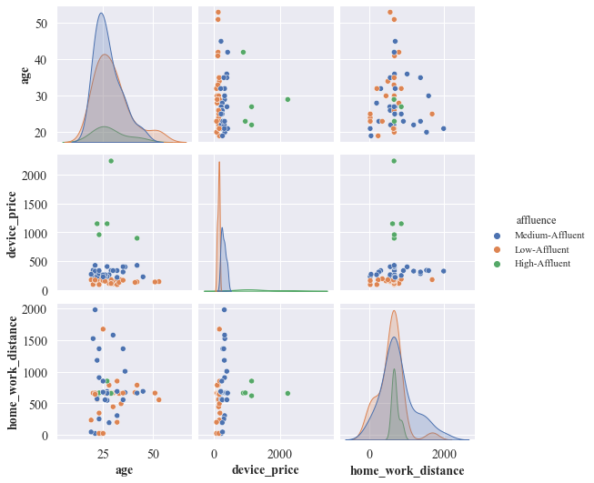

```python
pairplot_cols = df[['age','device_price','home_work_distance','affluence']]
sns.pairplot(pairplot_cols,hue = 'affluence')
```

```python
df['make'] = np.where(df['make'].isin([9,10,11]),False, df['make'])
for i,j in zip(['vivo', 'sm', 'cph', 'rmx', 'mi', 'redmi'], ['vivo','samsung','oppo', 'realme', 'xiaomi', 'xiaomi']):
    for z in df['make'][df['make']==False].index:
        #print(z)
        if i in df[df.index==z]['model'][z]:
            #print(i)
            #df_new[df_new.index==z]['make']= j
            #df_new[df_new.index==z]['make'].replace('False',j,inplace=True)
            df['make'][z] = j
        else: continue
```

```python
medium_price_max = df[df["affluence"]=="Medium-Affluent"]["device_price"].max()
medium_price_max
```

```
429.0
```

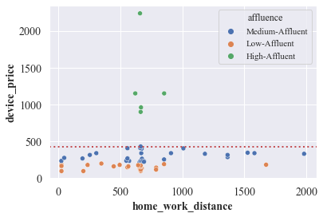

```python
sns.scatterplot(data=df, x="home_work_distance", y="device_price", hue="affluence")
plt.axhline(medium_price_max, color='r', linestyle=':', linewidth=2)
```

```python
df[df["device_price"]==0][["device_price","make","model"]]
```

|  | device_price | make | model |
| --- | --- | --- | --- |
| 0 | 0.0 | generic | android 7.0 |
| 9 | 0.0 | vivo | v2027 |
| 14 | 0.0 | xiaomi | poco f1 |
| 16 | 0.0 | vivo | v2026 |
| 27 | 0.0 | generic | android 11.0 |
| 40 | 0.0 | vivo | y53 1606 |
| 42 | 0.0 | huawei | chm-u01 |
| 48 | 0.0 | generic | android 11.0 |
| 52 | 0.0 | generic | android 10.0 |
| 57 | 0.0 | vivo | vivo 2007 |
| 61 | 0.0 | oppo | cph1989 |
| 63 | 0.0 | oppo | cph1821 |
| 65 | 0.0 | vivo | v2030 |
| 73 | 0.0 | generic | android 11.0 |
| 76 | 0.0 | samsung | sm-g950f |
| 77 | 0.0 | samsung | sm-a515f |
| 94 | 0.0 | xiaomi | mi 9t |
| 97 | 0.0 | samsung | sm-a600g |
| 99 | 0.0 | samsung | sm-g973n |

```python
df[df["model"]=="sm-a325f"][["make","model","device_price"]]
```

|  | make | model | device_price |
| --- | --- | --- | --- |
| 98 | samsung | sm-a325f | NaN |

```python
df[df["device_price"]==0]["model"].unique()
```

```
array(['android 7.0', 'v2027', 'poco f1', 'v2026', 'android 11.0',
       'y53 1606', 'chm-u01', 'android 10.0', 'vivo 2007', 'cph1989',
       'cph1821', 'v2030', 'sm-g950f', 'sm-a515f', 'mi 9t', 'sm-a600g',
       'sm-g973n'], dtype=object)
```

```python
df.loc[df.model == "sm-g950f", "device_price"] = 250
df.loc[df.model == 'sm-n950u', "device_price"] = 270
df.loc[df.model == 'redmi 4a', "device_price"] = 700
df.loc[df.model == 'v2027', "device_price"] = 100
df.loc[df.model == 'poco f1', "device_price"] = 429
df.loc[df.model == 'iphone', "device_price"] = 1150
df.loc[df.model == 'v2026', "device_price"] = 170
df.loc[df.model == 'rmx1941', "device_price"] = 116
df.loc[df.model == 'y53 1606', "device_price"] = 120
df.loc[df.model == 'chm-u01', "device_price"] = 130
df.loc[df.model == 'cph1909', "device_price"] = 143
df.loc[df.model == 'cph1803', "device_price"] = 160
df.loc[df.model == 'vivo 2007', "device_price"] = 160
df.loc[df.model == 'cph1989', "device_price"] = 490
df.loc[df.model == 'cph1821', "device_price"] = 140
df.loc[df.model == 'v2030', "device_price"] = 340
df.loc[df.model == 'sm-a515f', "device_price"] = 345
df.loc[df.model == 'redmi note 5a', "device_price"] = 120
df.loc[df.model == 'redmi 6a', "device_price"] = 96
df.loc[df.model == 'mi 9t', "device_price"] = 140
df.loc[df.model == 'sm-a600g', "device_price"] = 250
df.loc[df.model == 'sm-a325f', "device_price"] = 360
df.loc[df.model ==  'sm-g973n', "device_price"] = 500
```

```python
category = pd.cut(df.device_price, bins=[0,210,500,2236],labels=["Low-Affluent","Medium-Affluent","High-Affluent"])
```

```python
df.columns
```

```
Index(['index', 'affluence', 'age', 'age_group', 'app_usage', 'brands_visited',
       'carrier', 'device_age', 'device_price', 'gender', 'geo_behaviour',
       'home_desakel', 'home_geohash', 'home_kab', 'home_kec', 'home_lat',
       'home_lon', 'home_prop', 'interests', 'make', 'model', 'os',
       'os_version', 'place_categories', 'work_desakel', 'work_geohash',
       'work_kab', 'work_kec', 'work_lat', 'work_lon', 'work_prop',
       'home_work_distance'],
      dtype='object')
```

```python
df.insert(2,"affluence_copy",category)
```

```python
df_copy = df.copy()
```

```python
similar_columns(df_copy,"affluence","affluence_copy")
```

```
0
```

```python
df=df.drop(columns="affluence")
```

```python
df.rename(columns = {'affluence_copy':'affluence'}, inplace = True)
```

```python
df.isnull().sum()
```

```
index                  0
affluence             12
age                    0
age_group              0
app_usage             51
brands_visited        71
carrier                9
device_age            29
device_price           7
gender                 6
geo_behaviour         47
home_desakel          12
home_geohash          10
home_kab              12
home_kec              12
home_lat              11
home_lon              11
home_prop             12
interests             48
make                   5
model                  5
os                     0
os_version             0
place_categories      46
work_desakel           4
work_geohash           4
work_kab               4
work_kec               4
work_lat               4
work_lon               4
work_prop              4
home_work_distance    11
dtype: int64
```

```python
df = df[df.device_price != 0]
```

```python
df = df[df['device_price'].notna()]
```

```python
df.affluence.value_counts()
```

```
Medium-Affluent    41
Low-Affluent       40
High-Affluent       7
Name: affluence, dtype: int64
```

```python
medium = df[df["affluence"]=="Medium-Affluent"]
```

```python
medium.describe()
```

|  | age | device_price | home_lat | home_lon | work_lat | work_lon | home_work_distance |
| --- | --- | --- | --- | --- | --- | --- | --- |
| count | 41.000000 | 41.000000 | 38.000000 | 38.000000 | 39.000000 | 39.000000 | 38.000000 |
| mean | 28.512195 | 314.682927 | -0.089564 | 1.876147 | -0.091388 | 1.879099 | 736.563428 |
| std | 8.234446 | 77.275623 | 0.051508 | 0.070696 | 0.051621 | 0.071670 | 401.087114 |
| min | 19.000000 | 215.000000 | -0.151253 | 1.722529 | -0.151253 | 1.721738 | 24.618275 |
| 25% | 22.000000 | 250.000000 | -0.119806 | 1.860695 | -0.120142 | 1.860395 | 566.235487 |
| 50% | 27.000000 | 315.000000 | -0.108119 | 1.864527 | -0.108373 | 1.864518 | 663.581990 |
| 75% | 32.000000 | 345.000000 | -0.107379 | 1.879258 | -0.106028 | 1.879222 | 690.705546 |
| max | 51.000000 | 500.000000 | 0.062354 | 2.169660 | 0.062905 | 2.169660 | 1980.654092 |

```python
low = df[df["affluence"]=="Low-Affluent"]
```

```python
low.describe()
```

|  | age | device_price | home_lat | home_lon | work_lat | work_lon | home_work_distance |
| --- | --- | --- | --- | --- | --- | --- | --- |
| count | 40.000000 | 40.000000 | 38.000000 | 38.000000 | 39.000000 | 39.000000 | 38.000000 |
| mean | 30.175000 | 145.350000 | -0.102138 | 1.909932 | -0.102655 | 1.908481 | 609.162733 |
| std | 9.131202 | 29.409182 | 0.039861 | 0.087586 | 0.039328 | 0.087226 | 398.170843 |
| min | 19.000000 | 96.000000 | -0.134259 | 1.699007 | -0.133780 | 1.698968 | 22.981692 |
| 25% | 23.000000 | 119.000000 | -0.120801 | 1.864527 | -0.120797 | 1.864479 | 496.176332 |
| 50% | 29.000000 | 145.500000 | -0.108769 | 1.866195 | -0.110099 | 1.866771 | 662.202390 |
| 75% | 33.250000 | 169.250000 | -0.107758 | 1.959225 | -0.107758 | 1.950525 | 664.132859 |
| max | 53.000000 | 198.000000 | 0.069480 | 2.178792 | 0.069592 | 2.178792 | 2126.887451 |

```python
high = df[df["affluence"]=="High-Affluent"]
```

```python
high.describe()
```

|  | age | device_price | home_lat | home_lon | work_lat | work_lon | home_work_distance |
| --- | --- | --- | --- | --- | --- | --- | --- |
| count | 7.000000 | 7.000000 | 6.000000 | 6.000000 | 7.000000 | 7.000000 | 6.000000 |
| mean | 28.428571 | 1177.857143 | -0.110742 | 1.877930 | -0.110741 | 1.876345 | 580.606608 |
| std | 6.579188 | 495.910754 | 0.011116 | 0.045277 | 0.010127 | 0.041552 | 285.836305 |
| min | 22.000000 | 700.000000 | -0.127067 | 1.837074 | -0.127069 | 1.837098 | 21.693527 |
| 25% | 25.000000 | 929.500000 | -0.116387 | 1.864244 | -0.114206 | 1.863583 | 629.827531 |
| 50% | 27.000000 | 1150.000000 | -0.108293 | 1.864822 | -0.108829 | 1.865117 | 661.009748 |
| 75% | 29.000000 | 1150.000000 | -0.107396 | 1.868386 | -0.108228 | 1.868917 | 665.849058 |
| max | 42.000000 | 2236.000000 | -0.094615 | 1.967237 | -0.094424 | 1.967199 | 853.031001 |

**IDEA: Jual HP untuk Medium affluent. dari situ bisa dikembangin berarti produk ini harus dibawah 500. liat dari orang-orang hpnya udah berapa lama. Dari situ bisa estimate projected sales dari device ini karna orang2 tsb bakal ganti hp, bisa hubungin jg sama persentase orang di Indonesia, bisa hubungin sama distance juga buat mobilitas orang-orangnya buat bahas battery life hp harus seberapa**

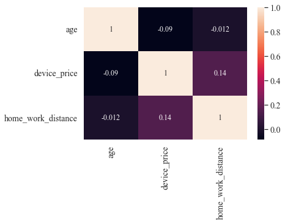

```python
corr = pairplot_cols.corr()
sns.heatmap(corr,annot=True)
```

```python
low_medium = df[df['affluence'].str.contains('High-Affluent')==False]
low_medium.head()
```

|  | index | affluence | age | age_group | app_usage | brands_visited | carrier | device_age | device_price | gender | geo_behaviour | home_desakel | home_geohash | home_kab | home_kec | home_lat | home_lon | home_prop | interests | make | model | os | os_version | place_categories | work_desakel | work_geohash | work_kab | work_kec | work_lat | … |
| --- | --- | --- | --- | --- | --- | --- | --- | --- | --- | --- | --- | --- | --- | --- | --- | --- | --- | --- | --- | --- | --- | --- | --- | --- | --- | --- | --- | --- | --- | --- |
| 1 | 0b92513072460e9b666813aa65****** | Medium-Affluent | 51.0 | 45-54 | NaN | NaN | telkomsel | NaN | 250.0 | female | NaN | Poris Plawad | qqgug5x | Kota Tangerang | Cipondoh | -0.107798 | 1.861665 | Banten | NaN | samsung | sm-g950f | android | 8 | NaN | Poris Plawad | qqgug5x | Kota Tangerang | Cipondoh | -0.107798 | … |
| 2 | 0d1172df74b8e8a1dd8045d38c****** | Medium-Affluent | 32.0 | 25-34 | NaN | Mercure Visitors,Apotek Visitors,Bakery Visito... | xl axiata | 2018_august | 339.0 | male | DIY Enthusiasts,Tourist Diners,Parents of Scho... | Pemecutan Klod | qw3ytw2 | Kota Denpasar | Denpasar Barat | -0.151253 | 2.010677 | Bali | NaN | oppo | cph1823 | android | 10 | Convenience Store Visitors,Supermarket Visitor... | Pemecutan Klod | qw3ytw2 | Kota Denpasar | Denpasar Barat | -0.151253 | … |
| 3 | 0df266e8010b16a2c85550ba1f****** | Low-Affluent | 25.0 | 25-34 | NaN | Apotek Visitors,Bank Mandiri Visitors,Wellcomm... | telkomsel | 2019_june | 182.0 | male | Job Seekers,In-Market Insurance Buyers,3 Star ... | Titiwungen Selatan | wb2b2sw | Kota Manado | Sario | 0.025754 | 2.178792 | Sulawesi Utara | Arts and Crafts,Photography,Hobbies & Interest... | vivo | vivo 1904 | android | 9 | Hospitals, Clinics And Medical Centers Visitor... | Titiwungen Selatan | wb2b2sw | Kota Manado | Sario | 0.025754 | … |
| 4 | 116a9523918e46bfa2bd5a6077****** | Medium-Affluent | 28.0 | 25-34 | SOCIAL | NaN | xl axiata | NaN | 270.0 | male | NaN | Balong Gede | qqu88et | Kota Bandung | Regol | -0.120837 | 1.878108 | Jawa Barat | NaN | samsung | sm-n950u | android | 9 | NaN | Balong Gede | qqu88em | Kota Bandung | Regol | -0.120861 | … |
| 7 | 1a284ca6cddf1a7376c7c35bc4****** | Medium-Affluent | 27.0 | 25-34 | NaN | Mercure Hotel Visitors | telkomsel | 2019_may | 232.0 | male | In-Market Insurance Buyers,Tour Enthusiasts,Fr... | Bojong Nangka | qqgu3w1 | Tangerang | Kelapa Dua | -0.109092 | 1.860371 | Banten | Technology & Computing,Arts & Entertainment,Vi... | vivo | vivo 1901 | android | 11 | Hospitals, Clinics And Medical Centers Visitor... | Bojong Nangka | qqgu3v6 | Tangerang | Kelapa Dua | -0.109164 | … |

```python
low_medium = low_medium.join(low_medium.device_age.str.split(pat='_',expand=True))
low_medium.rename(columns = {0:'device_year', 1:'device_month'}, inplace = True)
low_medium
```

|  | index | affluence | age | age_group | app_usage | brands_visited | carrier | device_age | device_price | gender | geo_behaviour | home_desakel | home_geohash | home_kab | home_kec | home_lat | home_lon | home_prop | interests | make | model | os | os_version | place_categories | work_desakel | work_geohash | work_kab | work_kec | work_lat | … |
| --- | --- | --- | --- | --- | --- | --- | --- | --- | --- | --- | --- | --- | --- | --- | --- | --- | --- | --- | --- | --- | --- | --- | --- | --- | --- | --- | --- | --- | --- | --- |
| 1 | 0b92513072460e9b666813aa65****** | Medium-Affluent | 51.0 | 45-54 | NaN | NaN | telkomsel | NaN | 250.0 | female | NaN | Poris Plawad | qqgug5x | Kota Tangerang | Cipondoh | -0.107798 | 1.861665 | Banten | NaN | samsung | sm-g950f | android | 8 | NaN | Poris Plawad | qqgug5x | Kota Tangerang | Cipondoh | -0.107798 | … |
| 2 | 0d1172df74b8e8a1dd8045d38c****** | Medium-Affluent | 32.0 | 25-34 | NaN | Mercure Visitors,Apotek Visitors,Bakery Visito... | xl axiata | 2018_august | 339.0 | male | DIY Enthusiasts,Tourist Diners,Parents of Scho... | Pemecutan Klod | qw3ytw2 | Kota Denpasar | Denpasar Barat | -0.151253 | 2.010677 | Bali | NaN | oppo | cph1823 | android | 10 | Convenience Store Visitors,Supermarket Visitor... | Pemecutan Klod | qw3ytw2 | Kota Denpasar | Denpasar Barat | -0.151253 | … |
| 3 | 0df266e8010b16a2c85550ba1f****** | Low-Affluent | 25.0 | 25-34 | NaN | Apotek Visitors,Bank Mandiri Visitors,Wellcomm... | telkomsel | 2019_june | 182.0 | male | Job Seekers,In-Market Insurance Buyers,3 Star ... | Titiwungen Selatan | wb2b2sw | Kota Manado | Sario | 0.025754 | 2.178792 | Sulawesi Utara | Arts and Crafts,Photography,Hobbies & Interest... | vivo | vivo 1904 | android | 9 | Hospitals, Clinics And Medical Centers Visitor... | Titiwungen Selatan | wb2b2sw | Kota Manado | Sario | 0.025754 | … |
| 4 | 116a9523918e46bfa2bd5a6077****** | Medium-Affluent | 28.0 | 25-34 | SOCIAL | NaN | xl axiata | NaN | 270.0 | male | NaN | Balong Gede | qqu88et | Kota Bandung | Regol | -0.120837 | 1.878108 | Jawa Barat | NaN | samsung | sm-n950u | android | 9 | NaN | Balong Gede | qqu88em | Kota Bandung | Regol | -0.120861 | … |
| 7 | 1a284ca6cddf1a7376c7c35bc4****** | Medium-Affluent | 27.0 | 25-34 | NaN | Mercure Hotel Visitors | telkomsel | 2019_may | 232.0 | male | In-Market Insurance Buyers,Tour Enthusiasts,Fr... | Bojong Nangka | qqgu3w1 | Tangerang | Kelapa Dua | -0.109092 | 1.860371 | Banten | Technology & Computing,Arts & Entertainment,Vi... | vivo | vivo 1901 | android | 11 | Hospitals, Clinics And Medical Centers Visitor... | Bojong Nangka | qqgu3v6 | Tangerang | Kelapa Dua | -0.109164 | … |
| ... | ... | ... | ... | ... | ... | ... | ... | ... | ... | ... | ... | ... | ... | ... | ... | ... | ... | ... | ... | ... | ... | ... | ... | ... | ... | ... | ... | ... | ... | … |
| 95 | f3346612c2644741ec0d06712e****** | Medium-Affluent | 19.0 | 18-24 | TOOLS | NaN | telkomsel | NaN | 275.0 | NaN | NaN | Kajuanak | qw8r6eue | Bangkalan | Galis | -0.124649 | 1.971660 | Jawa Timur | NaN | samsung | sm-j320g | android | 5.1 | NaN | Pekadan | qw8r6mzu | Bangkalan | Galis | -0.124455 | … |
| 96 | f8c67b323137849019728c80db****** | Medium-Affluent | 32.0 | 25-34 | SOCIAL | NaN | telkomsel | 2017_july | 222.0 | male | Job Seekers,3 Star Hotel Travellers,DIY Enthus... | Kadu | qqgu957s | Tangerang | Curug | -0.108588 | 1.860039 | Banten | NaN | xiaomi | mi 5x | android | 8.1 | Hospitals, Clinics And Medical Centers Visitor... | Kadu | qqgu957s | Tangerang | Curug | -0.108588 | … |
| 97 | fa194cc9c066adce6591a24f47****** | Medium-Affluent | 21.0 | 18-24 | SOCIAL,TOOLS,PHOTOGRAPHY | Indomaret Visitors | three indonesia | 2002_january | 250.0 | male | Parents of School Children,Family Leisure Enth... | Bojong Kulur | qquh40w4 | Bogor | Gunung Putri | -0.110391 | 1.867001 | Jawa Barat | NaN | samsung | sm-a600g | android | 10 | Primary And Secondary Schools Visitors | Bojong Kulur | qquh40w4 | Bogor | Gunung Putri | -0.110391 | … |
| 98 | fbe626725d3b90d8ab35c3a95a****** | Medium-Affluent | 21.0 | 18-24 | NaN | NaN | xl axiata | 2021_february | 360.0 | male | Parents of School Children,Family Leisure Enth... | Harjamukti | qqu58qz5 | Kota Depok | Cimanggis | -0.111323 | 1.865683 | Jawa Barat | Freelance Writing,Technology & Computing,Hobbi... | samsung | sm-a325f | android | 11 | Supermarket Visitors,Grocery Store Visitors,Pr... | Harjamukti | qqu58qz5 | Kota Depok | Cimanggis | -0.111323 | … |
| 99 | fc64fb71fac4f093883174d89e****** | Medium-Affluent | 27.0 | 25-34 | SOCIAL,DATING | NaN | NaN | 2016_october | 500.0 | male | NaN | NaN | NaN | NaN | NaN | NaN | NaN | NaN | Business,Technology & Computing,Television,Web... | samsung | sm-g973n | android | 7 | NaN | Panggungharjo | qqw7rrjn | Bantul | Sewon | -0.136601 | … |

81 rows × 34 columns

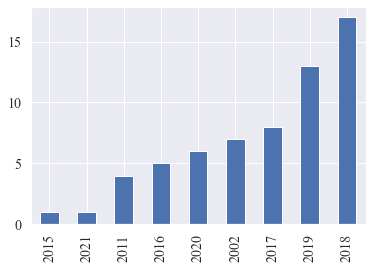

```python
low_medium.device_year.value_counts().sort_values().plot(kind = 'bar')
```

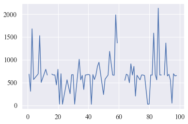

```python
plt.plot(low_medium["home_work_distance"])
```

### Analysis

In this analysis, we want to group our data based on affluence

#### Value Count Observations

```python
def value_count_object(Nama_kolom, df):
    list_a=[]
    lol=1
    for j in df[Nama_kolom]:
        if pd.isna(j):
            lol=1
        else:
            list_a.extend(j.split(','))

    final= pd.DataFrame(list_a).value_counts()
    return final
```

```python
#split column by ', ' to DataFrame
df_copy2 = df_copy["brands_visited"].str.split(',', expand=True)

#get all unique values to Series
vals = df_copy2.stack().drop_duplicates().reset_index(drop=True)

#if necessary add columns in df by unique values vals and change order of values
df_copy2 = (df_copy2.reindex(np.arange(len(vals)), axis=1)
        .apply(lambda x: vals.where(vals.isin(x)), axis=1)
        .add_prefix('brand'))
```

```python
df_copy = df.copy()
```

```python
df_copy = (pd.get_dummies(df_copy['brands_visited'].str.split(',', expand=True),
                    prefix='', prefix_sep='')
         .sum(level=0, axis=1))
```

```python
df_copy.corr()
```

|  | Apotek Visitors | Bank Mandiri Visitors | Bata Visitors | Hop Hop Visitors | Hush Puppies Visitors | Indomaret Visitors | Mazda Visitors | McDonald's Visitors | Mercure Hotel Visitors | Mercure Visitors | Pertamina Visitors | Pizza Hut Visitors | Play Visitors | Pullman Visitors | Sogo Visitors | Wood Visitors | Audi Visitors | Bank Mega Syariah Visitors | Gokana Visitors | Parkson Visitors | Ramayana Visitors | Roti bakar 88 Visitors | Veneta System Visitors | Alfamidi Visitors | Bakery Visitors | Bank BNI Syariah Visitors | Domino's Pizza Visitors | Dulux Visitors | Kidz Station Visitors | … |
| --- | --- | --- | --- | --- | --- | --- | --- | --- | --- | --- | --- | --- | --- | --- | --- | --- | --- | --- | --- | --- | --- | --- | --- | --- | --- | --- | --- | --- | --- | --- |
| Apotek Visitors | 1.000000 | 0.514265 | 0.437553 | 0.185651 | -0.038388 | 0.409013 | -0.038388 | 0.185651 | -0.038388 | 0.299425 | 0.291718 | 0.299425 | -0.067267 | -0.038388 | 0.299425 | -0.038388 | 0.299425 | -0.038388 | 0.299425 | -0.038388 | 0.299425 | 0.299425 | 0.425905 | 0.609449 | 0.530806 | 0.299425 | 0.327367 | 0.221462 | -0.038388 | … |
| Bank Mandiri Visitors | 0.514265 | 1.000000 | 0.577350 | 0.172917 | -0.040522 | 0.468304 | 0.283654 | 0.172917 | -0.040522 | -0.040522 | 0.523810 | 0.283654 | 0.118345 | -0.040522 | 0.283654 | -0.040522 | -0.040522 | 0.283654 | 0.283654 | -0.040522 | 0.283654 | -0.040522 | 0.403473 | 0.247436 | 0.352517 | 0.283654 | 0.307698 | 0.352517 | -0.040522 | … |
| Bata Visitors | 0.437553 | 0.577350 | 1.000000 | 0.332779 | -0.023395 | 0.336321 | -0.023395 | 0.332779 | -0.023395 | -0.023395 | 0.339079 | -0.023395 | -0.040996 | -0.023395 | -0.023395 | -0.023395 | -0.023395 | -0.023395 | -0.023395 | -0.023395 | 0.491304 | -0.023395 | 0.698836 | 0.214286 | 0.417764 | 0.491304 | 0.259641 | 0.417764 | -0.023395 | … |
| Hop Hop Visitors | 0.185651 | 0.172917 | 0.332779 | 1.000000 | -0.016350 | 0.133646 | -0.016350 | 0.488372 | -0.016350 | -0.016350 | 0.236961 | -0.016350 | -0.028649 | -0.016350 | -0.016350 | -0.016350 | -0.016350 | -0.016350 | -0.016350 | -0.016350 | -0.016350 | -0.016350 | 0.488372 | 0.332779 | -0.037429 | -0.016350 | 0.391543 | 0.291949 | -0.016350 | … |
| Hush Puppies Visitors | -0.038388 | -0.040522 | -0.023395 | -0.016350 | 1.000000 | -0.048599 | -0.011494 | -0.016350 | -0.011494 | -0.011494 | -0.031517 | -0.011494 | -0.020141 | -0.011494 | -0.011494 | -0.011494 | -0.011494 | -0.011494 | -0.011494 | 1.000000 | -0.011494 | -0.011494 | -0.016350 | -0.023395 | -0.026314 | -0.011494 | -0.020141 | -0.026314 | 1.000000 | … |
| ... | ... | ... | ... | ... | ... | ... | ... | ... | ... | ... | ... | ... | ... | ... | ... | ... | ... | ... | ... | ... | ... | ... | ... | ... | ... | ... | ... | ... | ... | … |
| Fladeo Visitors | 0.299425 | 0.283654 | 0.491304 | -0.016350 | -0.011494 | 0.236514 | -0.011494 | -0.016350 | -0.011494 | -0.011494 | 0.364698 | -0.011494 | -0.020141 | -0.011494 | -0.011494 | -0.011494 | -0.011494 | -0.011494 | -0.011494 | -0.011494 | -0.011494 | -0.011494 | 0.703031 | -0.023395 | 0.436812 | 1.000000 | -0.020141 | -0.026314 | -0.011494 | … |
| A&W Visitors | 0.299425 | 0.283654 | 0.491304 | -0.016350 | -0.011494 | 0.236514 | -0.011494 | -0.016350 | -0.011494 | -0.011494 | 0.364698 | -0.011494 | -0.020141 | -0.011494 | -0.011494 | -0.011494 | -0.011494 | -0.011494 | -0.011494 | -0.011494 | -0.011494 | -0.011494 | 0.703031 | -0.023395 | 0.436812 | 1.000000 | -0.020141 | -0.026314 | -0.011494 | … |
| Brooaster Chicken Visitors | 0.299425 | 0.283654 | 0.491304 | -0.016350 | -0.011494 | 0.236514 | -0.011494 | -0.016350 | -0.011494 | -0.011494 | 0.364698 | -0.011494 | -0.020141 | -0.011494 | -0.011494 | -0.011494 | -0.011494 | -0.011494 | -0.011494 | -0.011494 | -0.011494 | -0.011494 | 0.703031 | -0.023395 | 0.436812 | 1.000000 | -0.020141 | -0.026314 | -0.011494 | … |
| Optik Melawai Visitors | 0.299425 | 0.283654 | 0.491304 | 0.703031 | -0.011494 | 0.236514 | -0.011494 | 0.703031 | -0.011494 | -0.011494 | 0.364698 | -0.011494 | -0.020141 | -0.011494 | -0.011494 | -0.011494 | -0.011494 | -0.011494 | -0.011494 | -0.011494 | -0.011494 | -0.011494 | 0.703031 | 0.491304 | -0.026314 | -0.011494 | 0.570675 | 0.436812 | -0.011494 | … |
| Bunga Rampai Visitors | 0.299425 | 0.283654 | 0.491304 | 0.703031 | -0.011494 | 0.236514 | -0.011494 | 0.703031 | -0.011494 | -0.011494 | 0.364698 | -0.011494 | -0.020141 | -0.011494 | -0.011494 | -0.011494 | -0.011494 | -0.011494 | -0.011494 | -0.011494 | -0.011494 | -0.011494 | 0.703031 | 0.491304 | -0.026314 | -0.011494 | 0.570675 | 0.436812 | -0.011494 | … |

97 rows × 97 columns

```python
corr_matrix = df_copy.corr().abs()

# Select upper triangle of correlation matrix
upper = corr_matrix.where(np.triu(np.ones(corr_matrix.shape), k=1).astype(np.bool))

# Find features with correlation greater than 0.95
to_drop = [column for column in upper.columns if any(upper[column] < 0.4)]

# Drop features
df_copy.drop(to_drop, axis=1, inplace=True)
```

```python
value_count_object('interests',df=df)
```

```
Internet                              33
Technology & Computing                31
Computer Software and Applications    29
Business                              26
Web Conferencing                      24
                                      ..
Large Animals                          1
Logistics                              1
Marketing and Advertising              1
Metals Industry                        1
nvestors & Patents                     1
Length: 76, dtype: int64
```

```python
value_count_object('app_usage',df=df)
```

```
SOCIAL                32
TOOLS                 14
PHOTOGRAPHY           11
PRODUCTIVITY           7
COMMUNICATION          6
PERSONALIZATION        3
DATING                 2
BEAUTY                 1
COMICS                 1
EDUCATION              1
HEALTH AND FITNESS     1
LIFESTYLE              1
PHOTO AND VIDEO        1
dtype: int64
```

```python
df['carrier'].value_counts()
```

```
telkomsel                            36
xl axiata                            17
indosat internet network provider    13
three indonesia                       8
pt. wireless indonesia                6
pt wireless indonesia win             2
Name: carrier, dtype: int64
```

```python
df["make"].value_counts()
```

```
xiaomi     25
oppo       20
samsung    15
vivo       12
realme      8
apple       3
huawei      2
sony        1
infinix     1
asus        1
Name: make, dtype: int64
```

```python
df.head()
```

|  | index | affluence | age | age_group | app_usage | brands_visited | carrier | device_age | device_price | gender | geo_behaviour | home_desakel | home_geohash | home_kab | home_kec | home_lat | home_lon | home_prop | interests | make | model | os | os_version | place_categories | work_desakel | work_geohash | work_kab | work_kec | work_lat | … |
| --- | --- | --- | --- | --- | --- | --- | --- | --- | --- | --- | --- | --- | --- | --- | --- | --- | --- | --- | --- | --- | --- | --- | --- | --- | --- | --- | --- | --- | --- | --- |
| 1 | 0b92513072460e9b666813aa65****** | Medium-Affluent | 51.0 | 45-54 | NaN | NaN | telkomsel | NaN | 250.0 | female | NaN | Poris Plawad | qqgug5x | Kota Tangerang | Cipondoh | -0.107798 | 1.861665 | Banten | NaN | samsung | sm-g950f | android | 8 | NaN | Poris Plawad | qqgug5x | Kota Tangerang | Cipondoh | -0.107798 | … |
| 2 | 0d1172df74b8e8a1dd8045d38c****** | Medium-Affluent | 32.0 | 25-34 | NaN | Mercure Visitors,Apotek Visitors,Bakery Visito... | xl axiata | 2018_august | 339.0 | male | DIY Enthusiasts,Tourist Diners,Parents of Scho... | Pemecutan Klod | qw3ytw2 | Kota Denpasar | Denpasar Barat | -0.151253 | 2.010677 | Bali | NaN | oppo | cph1823 | android | 10 | Convenience Store Visitors,Supermarket Visitor... | Pemecutan Klod | qw3ytw2 | Kota Denpasar | Denpasar Barat | -0.151253 | … |
| 3 | 0df266e8010b16a2c85550ba1f****** | Low-Affluent | 25.0 | 25-34 | NaN | Apotek Visitors,Bank Mandiri Visitors,Wellcomm... | telkomsel | 2019_june | 182.0 | male | Job Seekers,In-Market Insurance Buyers,3 Star ... | Titiwungen Selatan | wb2b2sw | Kota Manado | Sario | 0.025754 | 2.178792 | Sulawesi Utara | Arts and Crafts,Photography,Hobbies & Interest... | vivo | vivo 1904 | android | 9 | Hospitals, Clinics And Medical Centers Visitor... | Titiwungen Selatan | wb2b2sw | Kota Manado | Sario | 0.025754 | … |
| 4 | 116a9523918e46bfa2bd5a6077****** | Medium-Affluent | 28.0 | 25-34 | SOCIAL | NaN | xl axiata | NaN | 270.0 | male | NaN | Balong Gede | qqu88et | Kota Bandung | Regol | -0.120837 | 1.878108 | Jawa Barat | NaN | samsung | sm-n950u | android | 9 | NaN | Balong Gede | qqu88em | Kota Bandung | Regol | -0.120861 | … |
| 6 | 1314e708133129975aaf64c444****** | High-Affluent | 27.0 | 25-34 | SOCIAL,DATING | NaN | NaN | 2016_november | 700.0 | male | Job Seekers,Parents of School Children,Family ... | Dukuh Kupang | qw8nsfsh | Kota Surabaya | Dukuh Pakis | -0.127067 | 1.967237 | Jawa Timur | Business,Technology & Computing,Personal Finan... | xiaomi | redmi 4a | android | 6 | Hospitals, Clinics And Medical Centers Visitor... | Dukuh Kupang | qw8nsfd | Kota Surabaya | Dukuh Pakis | -0.127069 | … |

```python
df.to_csv("Customer Final 2.csv")
```